# Survey completion

There are 92 total responses in the survey dataset. Of these, 46 finished the survey (50%).

Across all 92 respondents, 77 provided consent (83.7%), including 100% of those who completed the survey.

Survey start dates ranged from 2024-05-20 to 2024-08-06.

**Figure: Survey accrual**

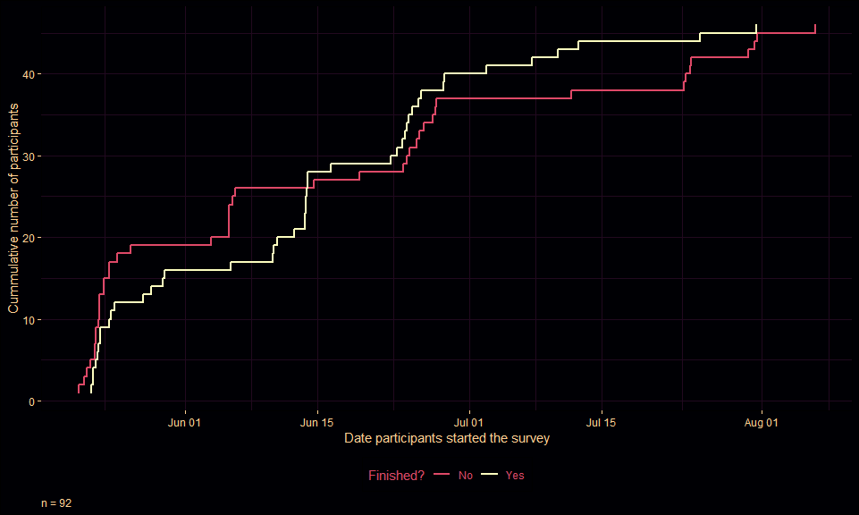

Survey accrual was similar for those who did vs didn’t finish the survey.

**Figure: Survey progress for those that didn’t finish the survey**

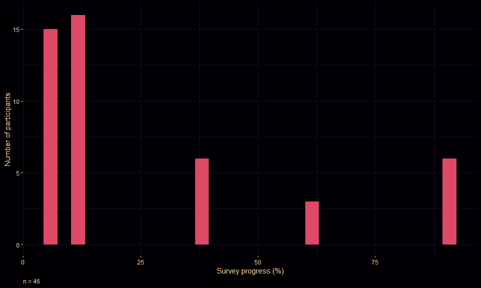

**Figure: Minutes spent on the survey for those that finished**

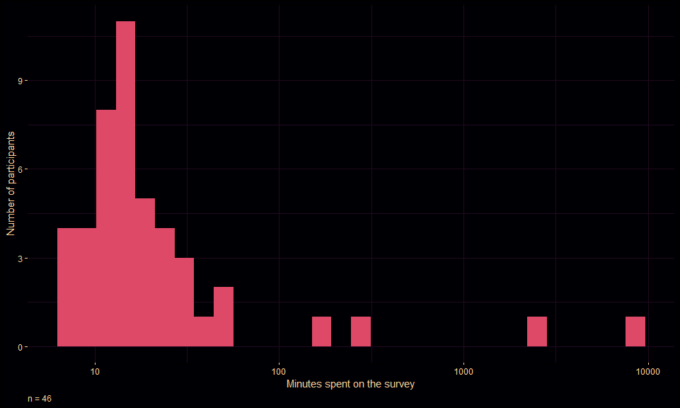

**Figure: Minutes spent on the survey for those that didn’t finish**

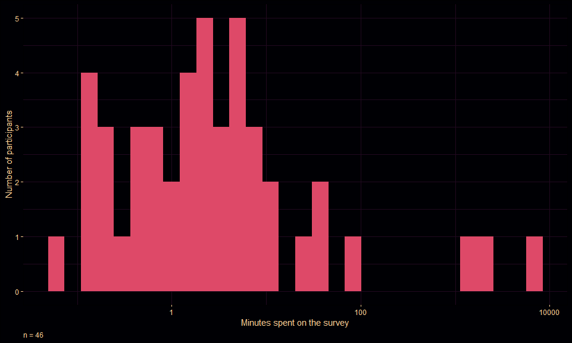

**Figure: Number of non-missing values across all survey variables for finishers**

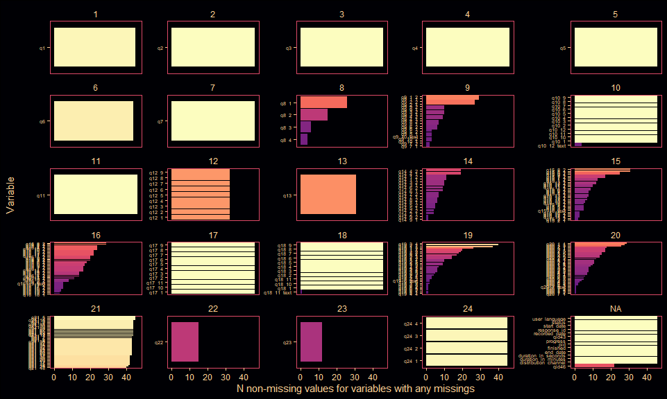

**Figure: Number of non-missing values across all survey variables for non-finishers**

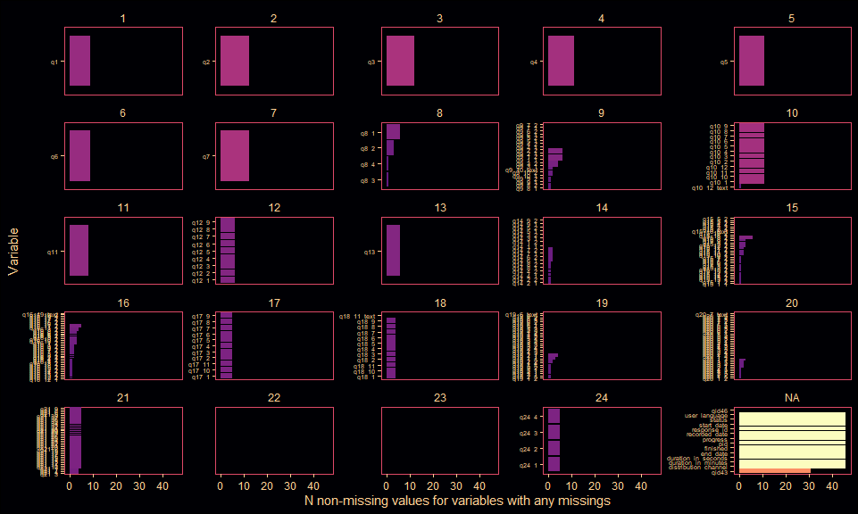

Finishers vs non-finishers on Q1-Q7

| **Characteristic** | **Finished survey?** **No** N = 46<sup>1</sup> | **Finished survey?** **Yes** N = 46<sup>1</sup> | **p-value**<sup>2</sup> |  |
| --- | --- | --- | --- | --- |
| What is your current career stage? |  |  |  | 0.2 |
| Undergraduate/ Masters student | 0/12 (0%) | 1/46 (2.2%) |  |  |
| Doctoral student | 0/12 (0%) | 3/46 (6.5%) |  |  |
| Early-career researcher (< 7 years post PhD) | 0/12 (0%) | 8/46 (17%) |  |  |
| Mid-career researcher (7-12 years post PhD) | 4/12 (33%) | 6/46 (13%) |  |  |
| Senior-career researcher (>12 years post PhD) | 8/12 (67%) | 28/46 (61%) |  |  |
| Missing values | 34 | 0 |  |  |
| How many years of research experience do you have in childhood obesity prevention trials?\n\n(please enter numeric values only) | 10 (7, 15) | 10 (5, 20) | >0.9 |  |
| Missing values | 34 | 0 |  |  |
| Have you undertaken training in trial methods? |  |  | 0.6 |  |
| No | 1/11 (9.1%) | 10/46 (22%) |  |  |
| Yes | 10/11 (91%) | 36/46 (78%) |  |  |
| Missing values | 35 | 0 |  |  |
| How many trials of interventions to prevent obesity, and/or to improve child health behaviours related to childhood obesity, in children from 0 to 5 years old have you been involved in to date? |  |  | 0.2 |  |
| 0 | 2/11 (18%) | 1/46 (2.2%) |  |  |
| 1 | 2/11 (18%) | 11/46 (24%) |  |  |
| 2 | 2/11 (18%) | 11/46 (24%) |  |  |
| 3 | 1/11 (9.1%) | 10/46 (22%) |  |  |
| 4 | 3/11 (27%) | 2/46 (4.3%) |  |  |
| 5 | 0/11 (0%) | 4/46 (8.7%) |  |  |
| 6 | 0/11 (0%) | 2/46 (4.3%) |  |  |
| 7 | 0/11 (0%) | 1/46 (2.2%) |  |  |
| 8 | 1/11 (9.1%) | 2/46 (4.3%) |  |  |
| more than 10 | 0/11 (0%) | 2/46 (4.3%) |  |  |
| Missing values | 35 | 0 |  |  |
| Are you currently involved in a childhood obesity prevention trial/s? |  |  | >0.9 |  |
| No | 5/12 (42%) | 20/46 (43%) |  |  |
| Yes, I am currently involved in 1 trial | 4/12 (33%) | 14/46 (30%) |  |  |
| Yes, I am currently involved in more than 1 trial | 3/12 (25%) | 12/46 (26%) |  |  |
| Missing values | 34 | 0 |  |  |

<sup>1</sup> n/N Non-missing (%); Median (Q1, Q3)  
<sup>2</sup> Pearson’s Chi-squared test; Wilcoxon rank sum test

List of Countries

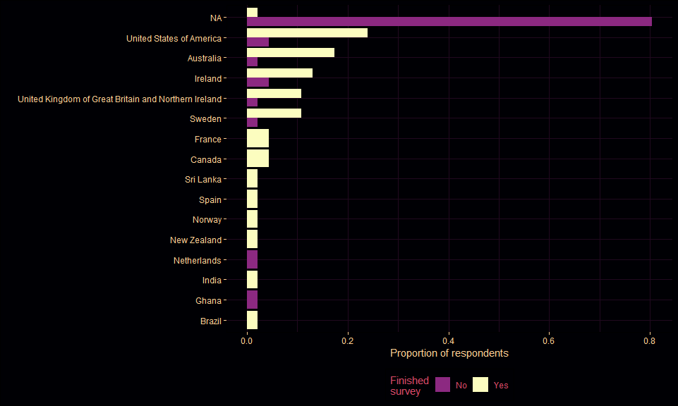

In what country/countries were the trials in which you are/were involved conducted?

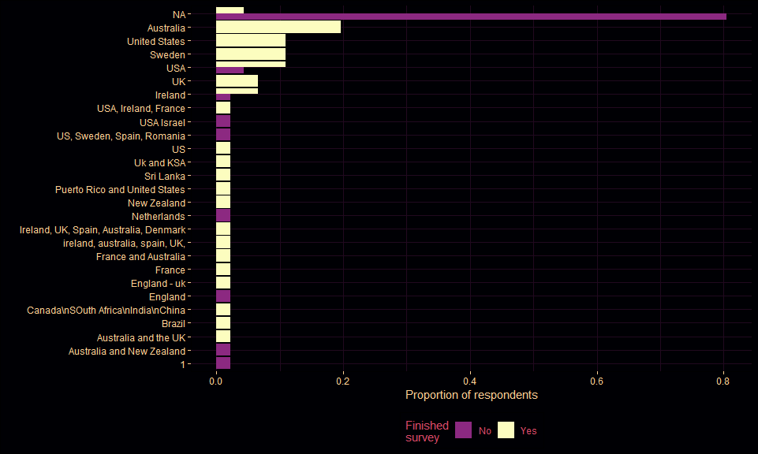

# Results

## (Q1-7) Repondent characteristics

From this point forward the dataset it limited to the 46 participants who completed the survey.

#### Table: Respondent characteristics

| **Characteristic** | **N = 46**<sup>1</sup> |
| --- | --- |
| What is your current career stage? |  |
| Undergraduate/ Masters student | 1/46 (2.2%) |
| Doctoral student | 3/46 (6.5%) |
| Early-career researcher (< 7 years post PhD) | 8/46 (17%) |
| Mid-career researcher (7-12 years post PhD) | 6/46 (13%) |
| Senior-career researcher (>12 years post PhD) | 28/46 (61%) |
| How many years of research experience do you have in childhood obesity prevention trials?\n\n(please enter numeric values only) | 10 (5, 20) |
| Have you undertaken training in trial methods? |  |
| No | 10/46 (22%) |
| Yes | 36/46 (78%) |
| How many trials of interventions to prevent obesity, and/or to improve child health behaviours related to childhood obesity, in children from 0 to 5 years old have you been involved in to date? |  |
| 0 | 1/46 (2.2%) |
| 1 | 11/46 (24%) |
| 2 | 11/46 (24%) |
| 3 | 10/46 (22%) |
| 4 | 2/46 (4.3%) |
| 5 | 4/46 (8.7%) |
| 6 | 2/46 (4.3%) |
| 7 | 1/46 (2.2%) |
| 8 | 2/46 (4.3%) |
| more than 10 | 2/46 (4.3%) |
| Are you currently involved in a childhood obesity prevention trial/s? |  |
| No | 20/46 (43%) |
| Yes, I am currently involved in 1 trial | 14/46 (30%) |
| Yes, I am currently involved in more than 1 trial | 12/46 (26%) |

<sup>1</sup> n/N Non-missing (%); Median (Q1, Q3)

#### Figure: List of Countries (Q1)

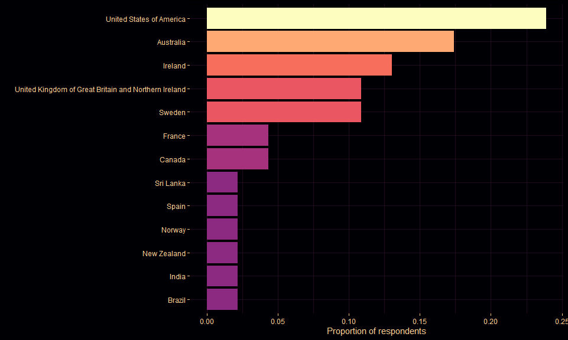

#### Table: List of Countries (Q1)

| **Characteristic** | **N = 14**<sup>1</sup> |
| --- | --- |
| q1 |  |
| Brazil | 1/13 (7.7%) |
| India | 1/13 (7.7%) |
| New Zealand | 1/13 (7.7%) |
| Norway | 1/13 (7.7%) |
| Spain | 1/13 (7.7%) |
| Sri Lanka | 1/13 (7.7%) |
| Canada | 1/13 (7.7%) |
| France | 1/13 (7.7%) |
| Sweden | 1/13 (7.7%) |
| United Kingdom of Great Britain and Northern Ireland | 1/13 (7.7%) |
| Ireland | 1/13 (7.7%) |
| Australia | 1/13 (7.7%) |
| United States of America | 1/13 (7.7%) |
| Missing values | 1 |
| q1_prop |  |
| 0.0217391304347826 | 7/14 (50%) |
| 0.0434782608695652 | 2/14 (14%) |
| 0.108695652173913 | 2/14 (14%) |
| 0.130434782608696 | 1/14 (7.1%) |
| 0.173913043478261 | 1/14 (7.1%) |
| 0.239130434782609 | 1/14 (7.1%) |

<sup>1</sup> n/N Non-missing (%)

#### Figure: What is your current career stage? (Q2)

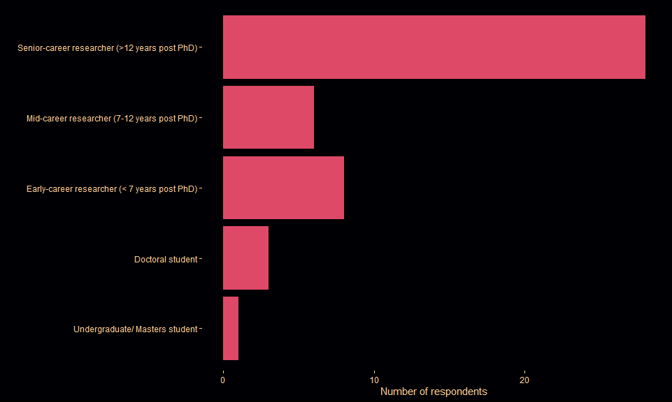

#### Figure: How many trials of interventions to prevent obesity, and/or to improve child health behaviours related to childhood obesity, in children from 0 to 5 years old have you been involved in to date? (Q5)

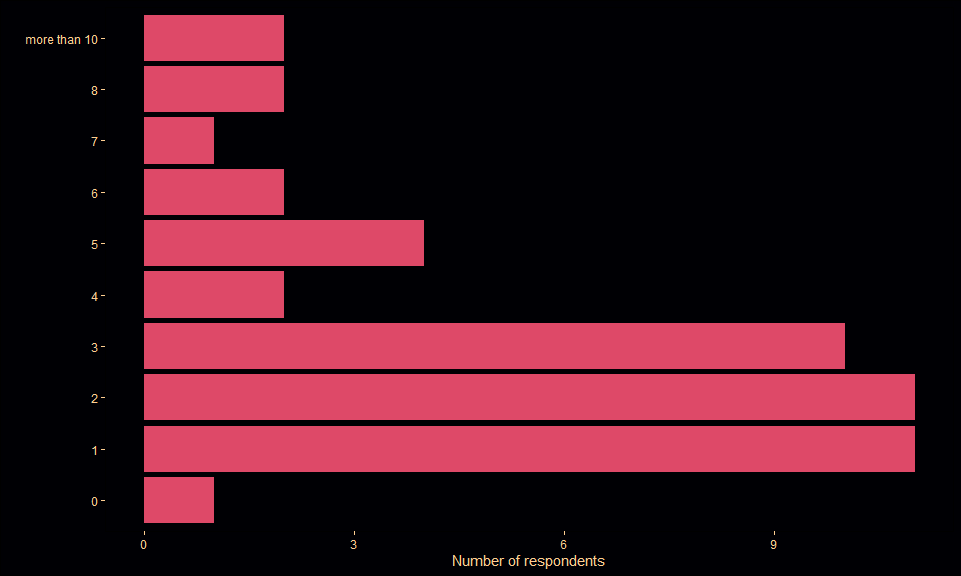

#### Figure: In what country/countries were the trials in which you are/were involved conducted? (Q6)

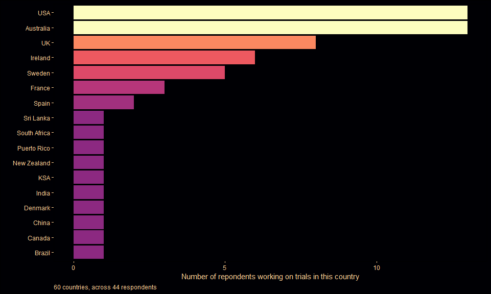

#### Table: In what country/countries were the trials in which you are/were involved conducted? (Q6)

| **Characteristic** | **N = 60**<sup>1</sup> |
| --- | --- |
| country |  |
| Brazil | 1/60 (1.7%) |
| Canada | 1/60 (1.7%) |
| China | 1/60 (1.7%) |
| Denmark | 1/60 (1.7%) |
| India | 1/60 (1.7%) |
| KSA | 1/60 (1.7%) |
| New Zealand | 1/60 (1.7%) |
| Puerto Rico | 1/60 (1.7%) |
| South Africa | 1/60 (1.7%) |
| Sri Lanka | 1/60 (1.7%) |
| Spain | 2/60 (3.3%) |
| France | 3/60 (5.0%) |
| Sweden | 5/60 (8.3%) |
| Ireland | 6/60 (10%) |
| UK | 8/60 (13%) |
| Australia | 13/60 (22%) |
| USA | 13/60 (22%) |

<sup>1</sup> n/N Non-missing (%)

## (Q8) Trial Status

#### Figure: Number of current trials for each respondent

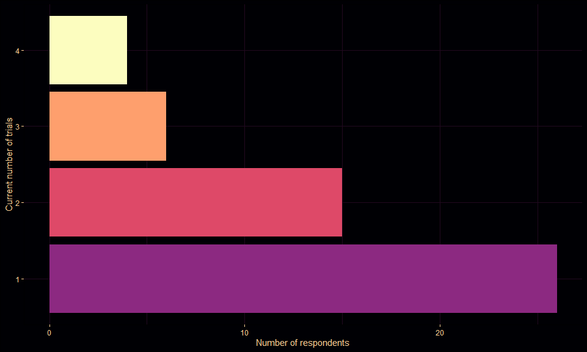

#### Figure: Status of all current trials

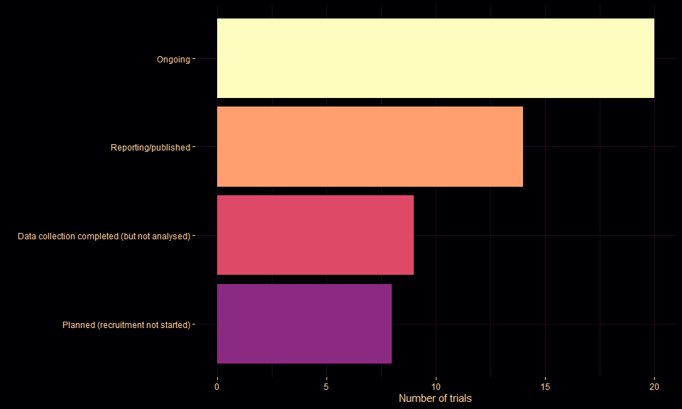

#### Figure: Number and status of all current trials, by respondent

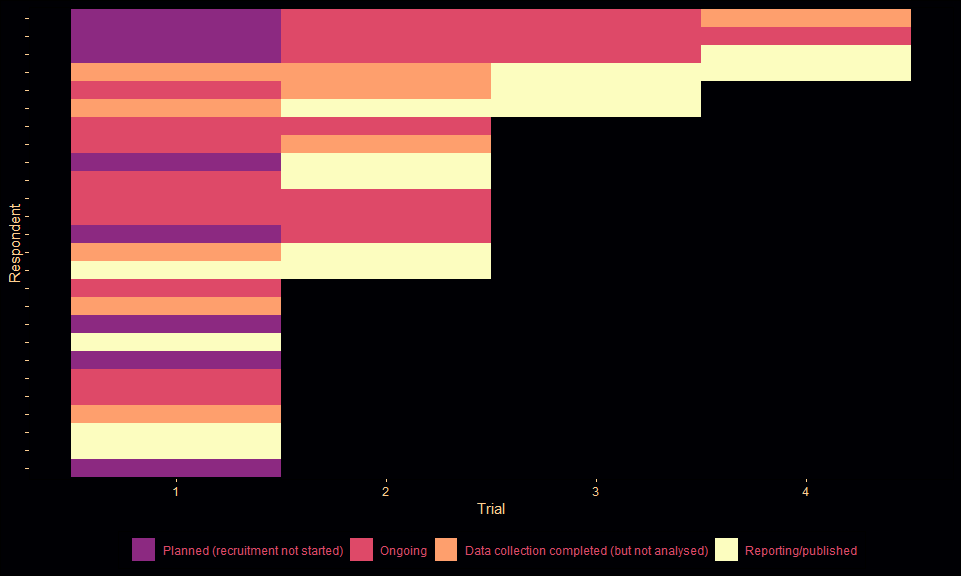

#### Table: At what stage is your current trial(s)?select one option for each trial you are currently involved in - Trial 1-4

| **Characteristic** | **N = 46**<sup>1</sup> |
| --- | --- |
| At what stage is your current trial(s)?\n\nPlease select one option for each trial you are currently involved in - Trial 1 |  |
| Planned (recruitment not started) | 5/26 (19%) |
| Ongoing | 9/26 (35%) |
| Data collection completed (but not analysed) | 7/26 (27%) |
| Reporting/published | 5/26 (19%) |
| Missing values | 20 |
| At what stage is your current trial(s)?\n\nPlease select one option for each trial you are currently involved in - Trial 2 |  |
| Planned (recruitment not started) | 3/15 (20%) |
| Ongoing | 5/15 (33%) |
| Data collection completed (but not analysed) | 0/15 (0%) |
| Reporting/published | 7/15 (47%) |
| Missing values | 31 |
| At what stage is your current trial(s)?\n\nPlease select one option for each trial you are currently involved in - Trial 3 |  |
| Planned (recruitment not started) | 0/6 (0%) |
| Ongoing | 3/6 (50%) |
| Data collection completed (but not analysed) | 1/6 (17%) |
| Reporting/published | 2/6 (33%) |
| Missing values | 40 |
| At what stage is your current trial(s)?\n\nPlease select one option for each trial you are currently involved in - Trial 4 |  |
| Planned (recruitment not started) | 0/4 (0%) |
| Ongoing | 3/4 (75%) |
| Data collection completed (but not analysed) | 1/4 (25%) |
| Reporting/published | 0/4 (0%) |
| Missing values | 42 |

<sup>1</sup> n/N Non-missing (%)

## (Q9) Current and previous roles working on childhood obesity prevention trials

#### Figure: Current and previous roles working on childhood obesity prevention trials across all respondents

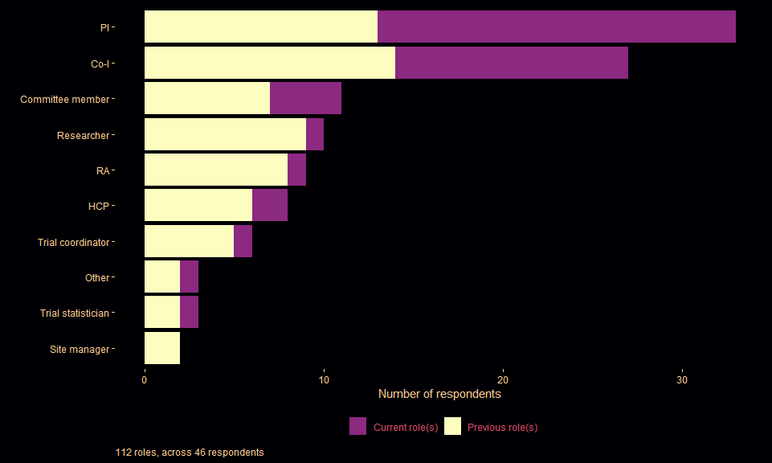

#### Free text

```
## [1] "Database manager; PhD student; We submitted a proposal to get funding for a childhood obesity trial"
```

## (Q10) Methods for identifying outcomes

#### Figure: Methods for identifying outcomes as reported across all respondents

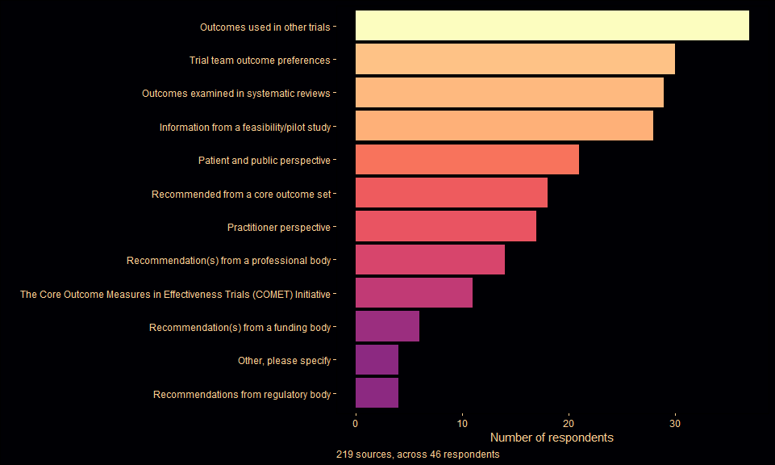

#### Free text

```
## [1] "WHO ICF Core Outcome Sets; Innovative ideas from teams; Outcomes come from previous trials (under this body of work) - based on the protocol of this trial, it is possible to understand what the outcomes would come from but I couldn't identify them off the top of my head.; Causal logic model"
```

## (Q11 & 12) Familiarity with core outcome sets

Among the 46 respondents, 32 indicated they had heard of, or were familiar with, core outcome sets prior to taking the survey.

#### Figure: Sources of previous exposure to core outcome sets

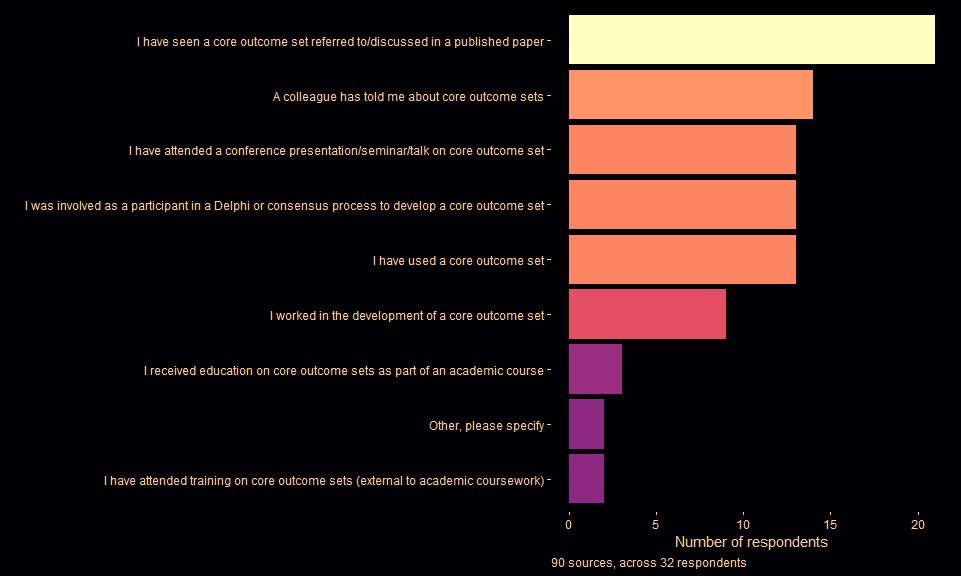

Note: I don’t see an actual open text variable associated with this set of responses.

## (Q13) Familarity with existing core outcomes sets for childhood obesity trials

#### Table: Familarity with existing core outcomes sets for childhood obesity trials

| **Characteristic** | **N = 46**<sup>1</sup> |
| --- | --- |
| Are you familiar with these core outcome sets? |  |
| No, I am not familiar with either core outcome set | 5/31 (16%) |
| Yes, I am familiar with both core outcome sets | 20/31 (65%) |
| Yes, I am familiar with the EPOCH core outcome set for obesity prevention up to 5 years only | 6/31 (19%) |
| Missing values | 15 |

<sup>1</sup> n/N Non-missing (%)

## (Q14) Sources of familiarity with existing core outcomes sets for childhood obesity

#### Figure: Sources of previous exposure to core outcome sets

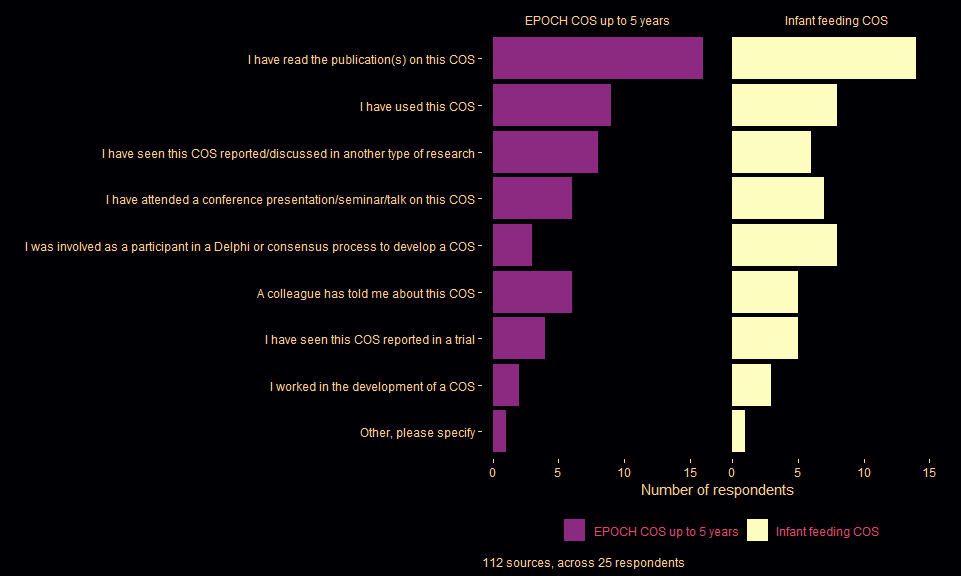

| **Characteristic** | **N**<sup>1</sup> | **EPOCH COS up to 5 years** N = 55<sup>2</sup> | **Infant feeding COS** N = 57<sup>2</sup> |
| --- | --- | --- | --- |
| Source | 112 |  |  |
| Other, please specify |  | 1/55 (1.8%) | 1/57 (1.8%) |
| I worked in the development of a COS |  | 2/55 (3.6%) | 3/57 (5.3%) |
| I have seen this COS reported in a trial |  | 4/55 (7.3%) | 5/57 (8.8%) |
| A colleague has told me about this COS |  | 6/55 (11%) | 5/57 (8.8%) |
| I was involved as a participant in a Delphi or consensus process to develop a COS |  | 3/55 (5.5%) | 8/57 (14%) |
| I have attended a conference presentation/seminar/talk on this COS |  | 6/55 (11%) | 7/57 (12%) |
| I have seen this COS reported/discussed in another type of research |  | 8/55 (15%) | 6/57 (11%) |
| I have used this COS |  | 9/55 (16%) | 8/57 (14%) |
| I have read the publication(s) on this COS |  | 16/55 (29%) | 14/57 (25%) |

<sup>1</sup> 112 sources endorsed by 25 respondents  
<sup>2</sup> n/N Non-missing (%)

Note: No actual open text field for “other”.

## (Q15) Barriers to using childhood obesity prevention core outcome set(s) in a trial

#### Figure: Barriers to using childhood obesity prevention core outcome set(s) in a trial

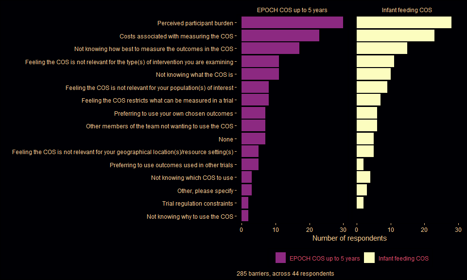

| **Characteristic** | **N**<sup>1</sup> | **EPOCH COS up to 5 years** N = 149<sup>2</sup> | **Infant feeding COS** N = 136<sup>2</sup> |
| --- | --- | --- | --- |
| Barrier | 285 |  |  |
| Not knowing why to use the COS |  | 2/149 (1.3%) | 0/136 (0%) |
| Trial regulation constraints |  | 2/149 (1.3%) | 2/136 (1.5%) |
| Other, please specify |  | 3/149 (2.0%) | 3/136 (2.2%) |
| Not knowing which COS to use |  | 3/149 (2.0%) | 4/136 (2.9%) |
| Preferring to use outcomes used in other trials |  | 5/149 (3.4%) | 2/136 (1.5%) |
| Feeling the COS is not relevant for your geographical location(s)/resource setting(s) |  | 5/149 (3.4%) | 5/136 (3.7%) |
| None |  | 7/149 (4.7%) | 5/136 (3.7%) |
| Other members of the team not wanting to use the COS |  | 7/149 (4.7%) | 6/136 (4.4%) |
| Preferring to use your own chosen outcomes |  | 7/149 (4.7%) | 6/136 (4.4%) |
| Feeling the COS restricts what can be measured in a trial |  | 8/149 (5.4%) | 7/136 (5.1%) |
| Feeling the COS is not relevant for your population(s) of interest |  | 8/149 (5.4%) | 9/136 (6.6%) |
| Not knowing what the COS is |  | 11/149 (7.4%) | 10/136 (7.4%) |
| Feeling the COS is not relevant for the type(s) of intervention you are examining |  | 11/149 (7.4%) | 11/136 (8.1%) |
| Not knowing how best to measure the outcomes in the COS |  | 17/149 (11%) | 15/136 (11%) |
| Costs associated with measuring the COS |  | 23/149 (15%) | 23/136 (17%) |
| Perceived participant burden |  | 30/149 (20%) | 28/136 (21%) |

<sup>1</sup> 285 sources endorsed by 44 respondents  
<sup>2</sup> n/N Non-missing (%)

#### Free text

```
## [1] "Self reported outcomes are unreliable andnot associated with long-term outcome. Physical activity is not associated with weight development in this age group. A large number of excellent studies have failed to affect long-term weight outcome. We need to identify new interventions and outcome…
```

## (Q16) Faciliators to using childhood obesity prevention core outcome set(s) in a trial

#### Figure: Faciliators to using childhood obesity prevention core outcome set(s) in a trial

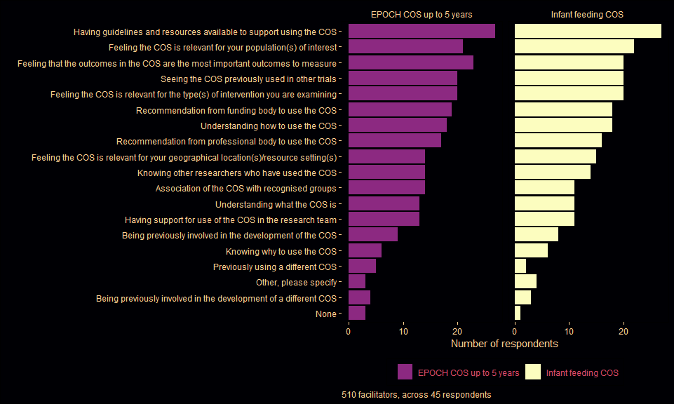

| **Characteristic** | **N**<sup>1</sup> | **EPOCH COS up to 5 years** N = 263<sup>2</sup> | **Infant feeding COS** N = 247<sup>2</sup> |
| --- | --- | --- | --- |
| Facilitator | 510 |  |  |
| None |  | 3/263 (1.1%) | 1/247 (0.4%) |
| Being previously involved in the development of a different COS |  | 4/263 (1.5%) | 3/247 (1.2%) |
| Other, please specify |  | 3/263 (1.1%) | 4/247 (1.6%) |
| Previously using a different COS |  | 5/263 (1.9%) | 2/247 (0.8%) |
| Knowing why to use the COS |  | 6/263 (2.3%) | 6/247 (2.4%) |
| Being previously involved in the development of the COS |  | 9/263 (3.4%) | 8/247 (3.2%) |
| Having support for use of the COS in the research team |  | 13/263 (4.9%) | 11/247 (4.5%) |
| Understanding what the COS is |  | 13/263 (4.9%) | 11/247 (4.5%) |
| Association of the COS with recognised groups |  | 14/263 (5.3%) | 11/247 (4.5%) |
| Knowing other researchers who have used the COS |  | 14/263 (5.3%) | 14/247 (5.7%) |
| Feeling the COS is relevant for your geographical location(s)/resource setting(s) |  | 14/263 (5.3%) | 15/247 (6.1%) |
| Recommendation from professional body to use the COS |  | 17/263 (6.5%) | 16/247 (6.5%) |
| Understanding how to use the COS |  | 18/263 (6.8%) | 18/247 (7.3%) |
| Recommendation from funding body to use the COS |  | 19/263 (7.2%) | 18/247 (7.3%) |
| Feeling the COS is relevant for the type(s) of intervention you are examining |  | 20/263 (7.6%) | 20/247 (8.1%) |
| Seeing the COS previously used in other trials |  | 20/263 (7.6%) | 20/247 (8.1%) |
| Feeling that the outcomes in the COS are the most important outcomes to measure |  | 23/263 (8.7%) | 20/247 (8.1%) |
| Feeling the COS is relevant for your population(s) of interest |  | 21/263 (8.0%) | 22/247 (8.9%) |
| Having guidelines and resources available to support using the COS |  | 27/263 (10%) | 27/247 (11%) |

<sup>1</sup> 510 facilitators endorsed by 45 respondents  
<sup>2</sup> n/N Non-missing (%)

#### Free text

```
## [1] "more funding; clear-cut scientific evidence that they are effective in long-term studies, i.e., 4 years or more. There is no association between short term and long term studies. In many reviews 6 month outcomes are used to demonstrate a preventive effect. 6 months is too short to demonstrat…
```

## (Q17) Sources to identify outcomes in childhood obesity prevention trials

#### Figure: Sources to identify outcomes in childhood obesity prevention trials

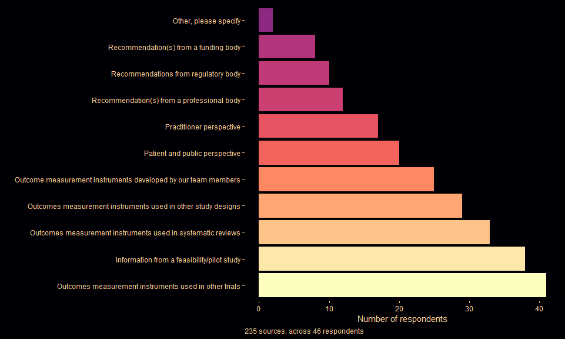

| **Characteristic** | **N**<sup>1</sup> | **N = 235**<sup>2</sup> |
| --- | --- | --- |
| Sources | 235 |  |
| Outcomes measurement instruments used in other trials |  | 41/235 (17%) |
| Information from a feasibility/pilot study |  | 38/235 (16%) |
| Outcomes measurement instruments used in systematic reviews |  | 33/235 (14%) |
| Outcomes measurement instruments used in other study designs |  | 29/235 (12%) |
| Outcome measurement instruments developed by our team members |  | 25/235 (11%) |
| Patient and public perspective |  | 20/235 (8.5%) |
| Practitioner perspective |  | 17/235 (7.2%) |
| Recommendation(s) from a professional body |  | 12/235 (5.1%) |
| Recommendations from regulatory body |  | 10/235 (4.3%) |
| Recommendation(s) from a funding body |  | 8/235 (3.4%) |
| Other, please specify |  | 2/235 (0.9%) |

<sup>1</sup> 235 sources endorsed by 46 respondents  
<sup>2</sup> n/N Non-missing (%)

Note: No actual free text field for “other” responses.

## (Q18) Currently planned/used outcomes

#### Figure: Currently planned/used outcomes in childhood obesity prevention interventions.

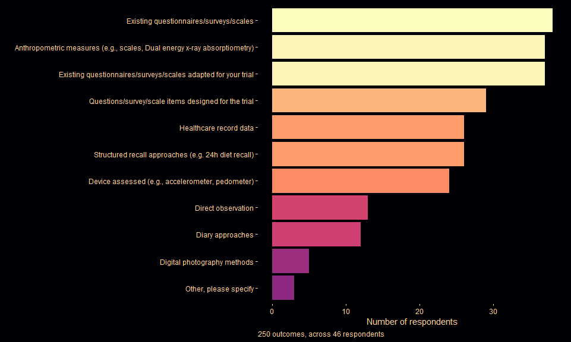

#### Free text

```
## [1] "Physical tests: exercise tests, motor function tests"
```

## (Q19) Administration

#### Figure: Route and method of administration across all responses

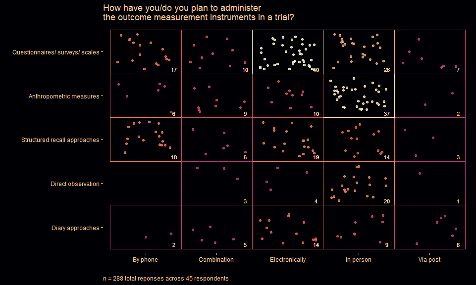

#### Table: Route and method of administration across all responses

|  | Method Anthropometric measures | Method Diary approaches | Method Direct observation | Method Questionnaires/ surveys/ scales | Method Structured recall approaches | Total |  |
| --- | --- | --- | --- | --- | --- | --- | --- |
| Route |  |  |  |  |  |  |  |
| By phone | 6 (2.1%) | 2 (0.7%) | 0 (0%) | 17 (5.9%) | 18 (6.3%) | 43 (15%) |  |
| Combination | 9 (3.1%) | 5 (1.7%) | 3 (1.0%) | 10 (3.5%) | 6 (2.1%) | 33 (11%) |  |
| Electronically | 10 (3.5%) | 14 (4.9%) | 4 (1.4%) | 40 (14%) | 19 (6.6%) | 87 (30%) |  |
| In person | 37 (13%) | 9 (3.1%) | 20 (6.9%) | 26 (9.0%) | 14 (4.9%) | 106 (37%) |  |
| Via post | 2 (0.7%) | 6 (2.1%) | 1 (0.3%) | 7 (2.4%) | 3 (1.0%) | 19 (6.6%) |  |
| Total | 64 (22%) | 36 (13%) | 28 (9.7%) | 100 (35%) | 60 (21%) | 288 (100%) |  |

#### Figure: Route and method of administration across all responses

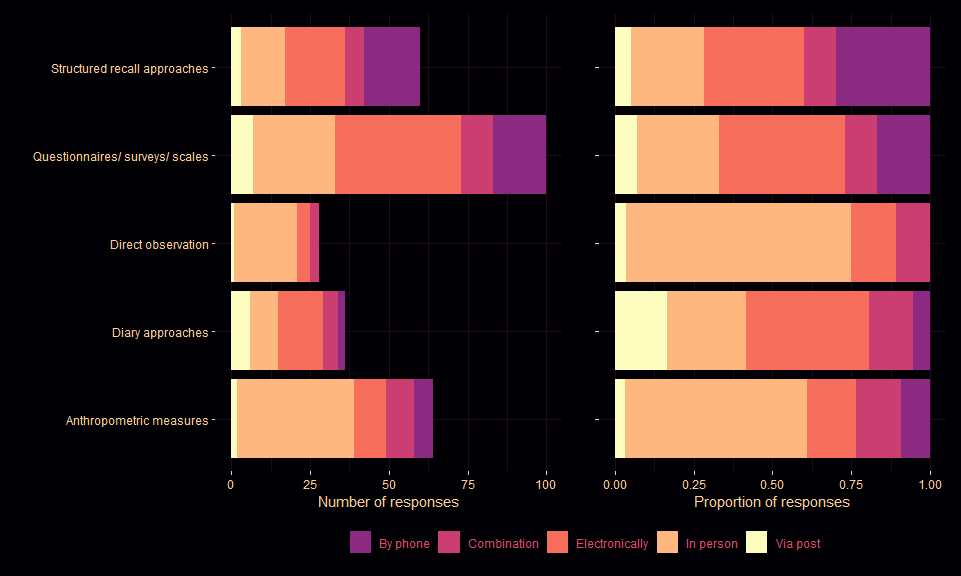

#### Figure: Method of administration across all responses

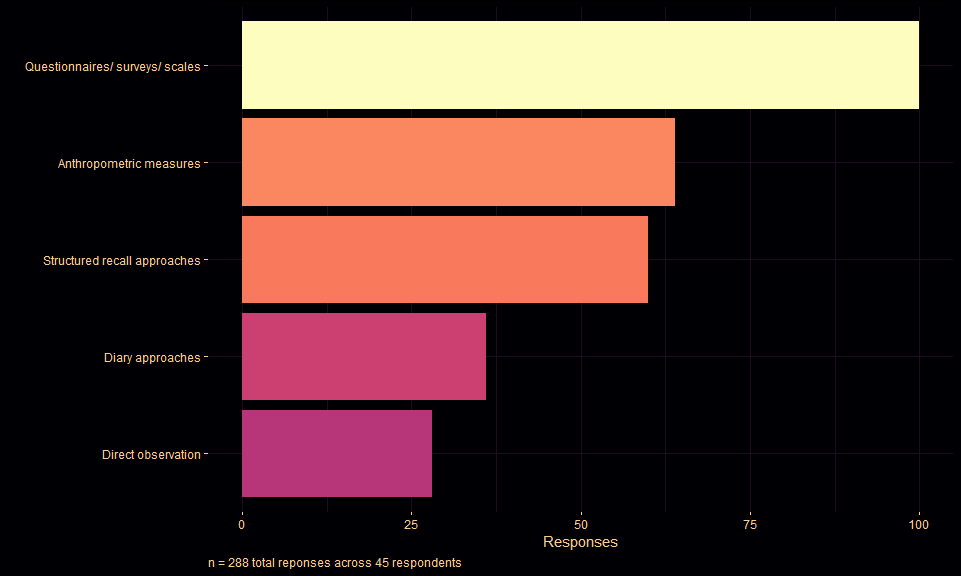

#### Figure: Route of administration across all responses

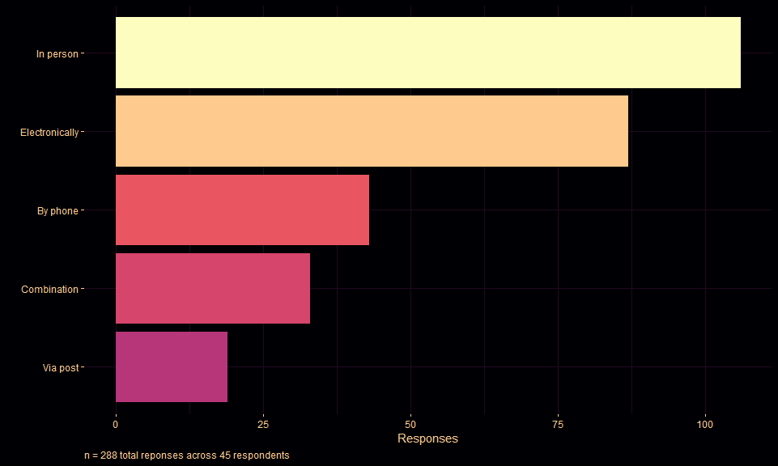

#### Figure: Method of administration - In person

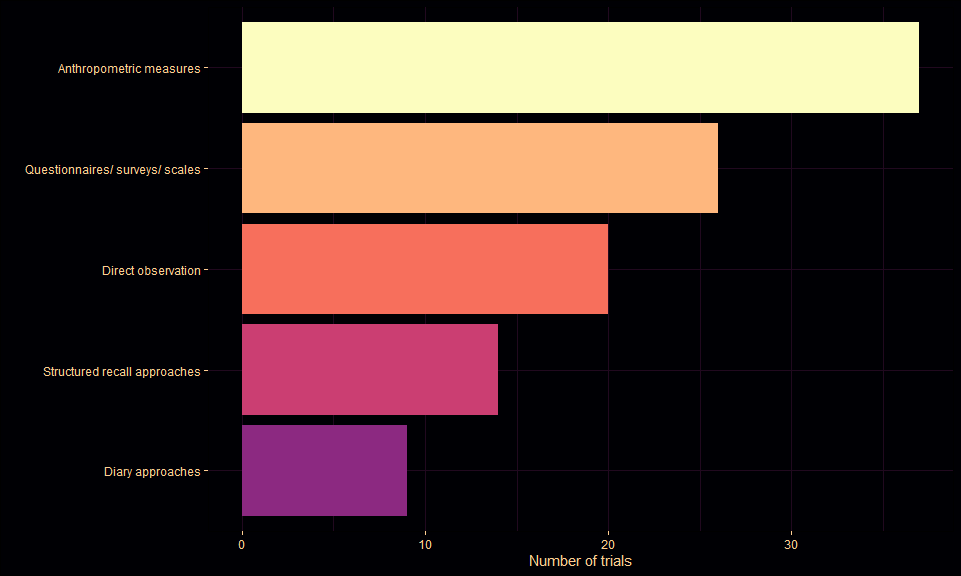

#### Figure: Method of administration - Electronically

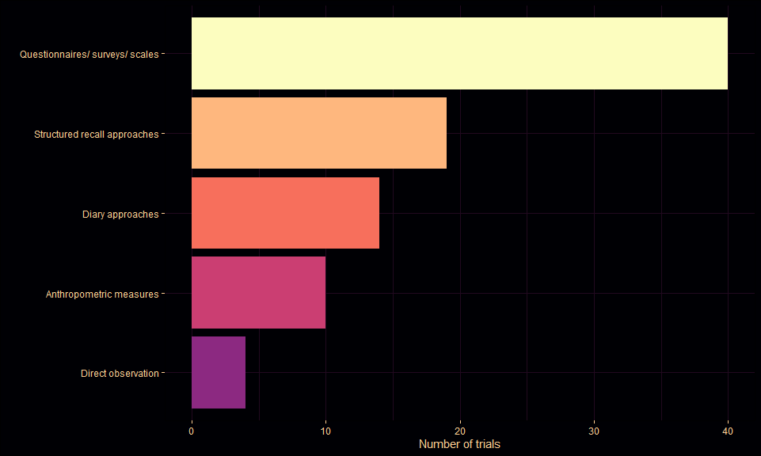

#### Figure: Method of administration - By phone

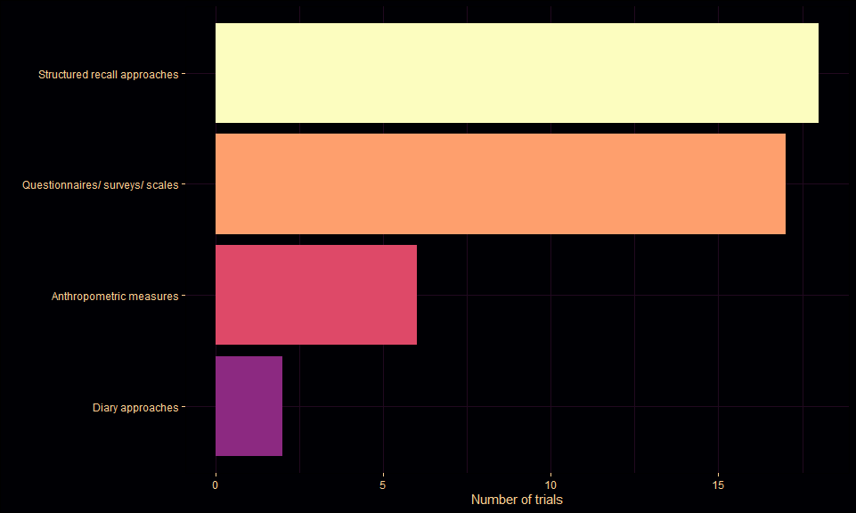

#### Figure: Method of administration - Via post

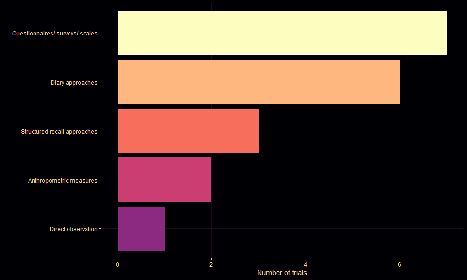

#### Figure: Method of administration - Combination

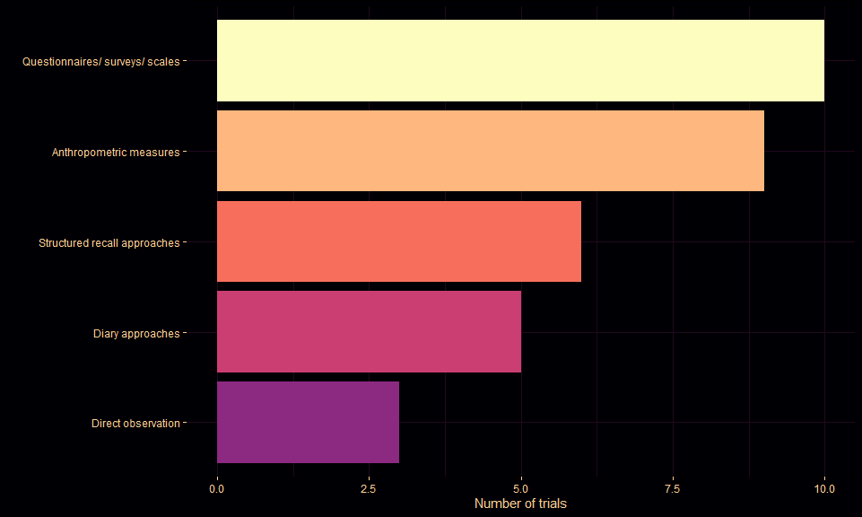

#### Free text

```
## [1] NA
## [2] "0"
## [3] "Anthropometric measures"
## [4] "Gave participants options of how they wanted to complete the survey"
## [5] "from usual pediatric visit"
```